# A Roadmap for ICJIA Data Portal Application

Bobae Kang

March 20, 2018

## Agenda

- Challenge
- Dashboard-oriented approach
- Data portal approach
- CKAN framework
- Our vision
- Path forward

# Challenge

How do we make our *data*  
more *accessible*?

## Key concerns

- Encouraging more use cases and public engagement
- Sustainability/ease of maintanence
- User-friendly interface

# Dashboard-oriented approach

## Pros and cons

Pros

- Visually appealing
- Interactivity
- Possibility to control the message

Cons

- High cost of production/maintanence
- Difficult to manage
- Product-centric approach
- Limited utility

# Data portal approach

A data portal does *not* preclude creation of dashboards!

## What is data portal?

> “A data portal is a site for storing a list of datasets with added features to facilitate accessing, viewing, and searching for any particular datasets.”
- Examples:
  - [**Data.gov**](https://www.data.gov/) by the US government
  - [**Chicago Data Portal**](https://data.cityofchicago.org/) by City of Chicago

## Why data portal?

- Proven utility
  - Many use cases (e.g. Data.gov, Chicago Data Portal)
- Great for storing/sharing multiple datasets
  - Suitable for the R&A unit’s “data clearinghouse” mission
  - Can have various formats of datasets (even dashboards)
- Ease of use and management
  - User interface
  - Access control

# CKAN framework

## What is CKAN?

- The **C**omprehensive **K**nowledge **A**rchive **N**etwork:

> “CKAN is an open-source DMS (data management system) for powering data hubs and data portals. CKAN makes it easy to publish, share and use data.”

## Use cases

- [**Data.gov**](https://www.data.gov/) by the US government
- [**European Data Portal**](https://www.europeandataportal.eu/) by the European Union
- [**opendata.swiss**](https://opendata.swiss/en/) by the Swiss government
- And more!

[figure not shown]

Data.gov main page

[figure not shown]

opendata.swiss main page

## Why use CKAN?

- An actively managed/maintained open-source project
  - Free, flexible, and up-to-date technology
- A rich set of features for a fully-functionl data portal
  - [**Extensive documentation**](http://docs.ckan.org/en/latest/) is available for various aspects/features
  - [**200+ extensions**](http://extensions.ckan.org/) exist to provide additional functionalities

## Useful features

- Flexibility and customizability in portal structure and look
- Elaborate access control
  - Organizations and groups
  - Capable of supporting a sustainable workflow
- Built-in visualizations
  - A simple “dashboard” view for each entry is available via [**an extension**](https://github.com/ckan/ckanext-dashboard)
- API for programmatic access to data
  - Great for research and application building
  - An entirely separate front-end interface is possible!

# Our vision

## General architecture

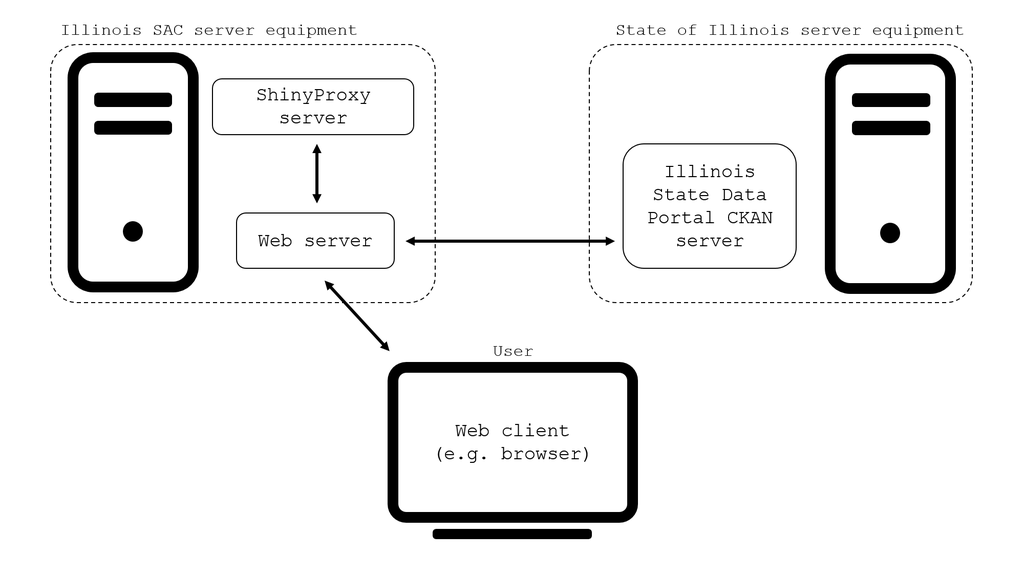

## General architecture (cont.)

- Using **data.illinois.gov** CKAN server as a backend DMS/storage
- Using **ShinyProxy** to deploy and manage staff-made dashboards/applications
- Creating a **front-end web application** for customized user interface/experience
  - This is the “Data Portal” that people will see and utilize to access ICJIA datasets, publications, and dashboards

## Portal structure

- **Main page**
  - Highlights, search bar, categories, some stats, etc.
- **Data**
  - Raw datasets (with metadata and simple visualizations)
- **Publications**
  - Articles
  - Dashboards (with metadata)
- **Applications**
  - Featuring user-made applications
- **About**
  - FQA, API documentation, Application guidelines, etc.

## Access Control

Access control model is implemented via data.illinois.gov. Select staff members will gain adminisrator rights and work with DoIT to build access control model that reflects ICJIA’s organizational structure

- **Users with permission**
  - upload/edit an item for internal view only
- **Mangers**
  - upload/edit/delete an item for internal and public views
- **Administrators**
  - manage organizations and groups
  - grant permissions as needed

## Contents

- **Data entries**
  - Raw datasets, dashboards, publications
  - Metadata: brief descriptions, data dictionary, etc.
  - Tags for grouping/classifying entires
  - Data explorer and visualization views
  - API for programmatic access/use of data
- **Publications**
  - [**Existing articles**](http://www.icjia.state.il.us/articles) on the current website
  - New articles
    - interactive articles
  - Dashboards

[figure not shown]

Data entry; image from CKAN Documentation

[figure not shown]

“View” options; image from CKAN Documentation

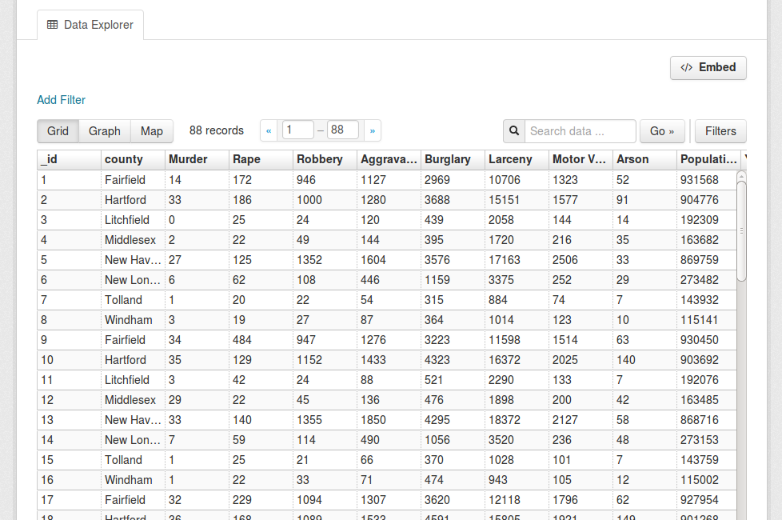

“Data Explorer” view; image from CKAN Documentation

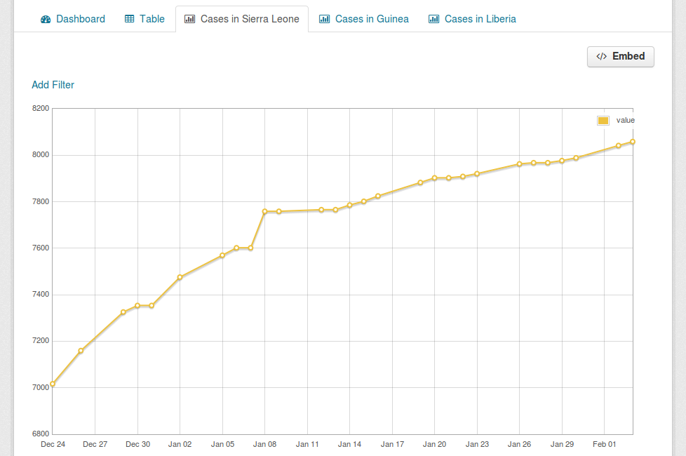

Built-in graph; image from CKAN Documentation

[figure not shown]

Embedding a webpage; image from CKAN Documentation

[figure not shown]

Article page example

## User engagement

- Application programming interface (API)
  - Facilitating data access for research projects or building applications
- User-made applications
  - Featuring applications meeting our standard
  - Providing an incentive to use our data -> more use cases
- Open-source contributions
- Outreach effort
  - Raising awareness and offering trainings on our UI/API
  - Hosting a “data challenge”? (e.g. [**2015 Divvy Data Challenge**](http://www.smartchicagocollaborative.org/divvy-announces-2015-divvy-data-challenge/))

[figure not shown]

Applications page example

# Path forward

## Internal timeline

| Time | Task |
| --- | --- |
| 2018 1Q | Proof of concept (demo); 2018 SJS grant application |
| 2018 2Q | Developing a design a data categorization schema and an access control model |
| 2018 3Q | Migrating datasets and articles; start creating additional contents (dashboards, etc) |
| 2018 4Q | Building the application; testing with select internal users; creating documentations |
| 2019 1Q | Lauching the application; training internal users |
| 2019 2Q | Outreach for user engagement (e.g. Chi Hack Night, Universities) |
| 2019 3Q | Ongoing user engagement; submitting final report to BJS |

## Grant application timeline

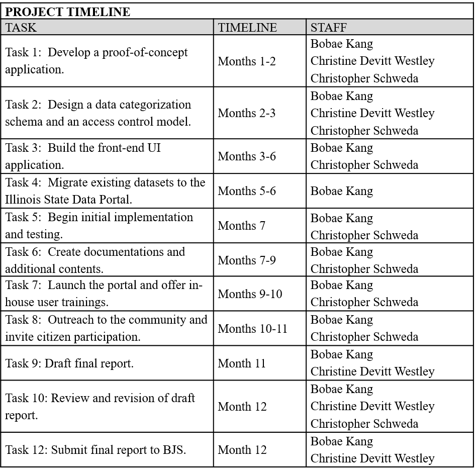